# KN-NBA

2022-05-10

## Presentation Overview (Bennett)

We plan to highlight the more complex functions of R, using concepts like **K-Nearest Neighbors (KNN)** and **Linear Regression**, and incorporating them into data from the NBA Playoffs.

For more details on the data-sets we will be using in our Final Project, click on the following links below: https://www.basketball-reference.com/leagues/NBA_2022.html#all_shooting_teamopponent

## Wins vs. Simple Rating System

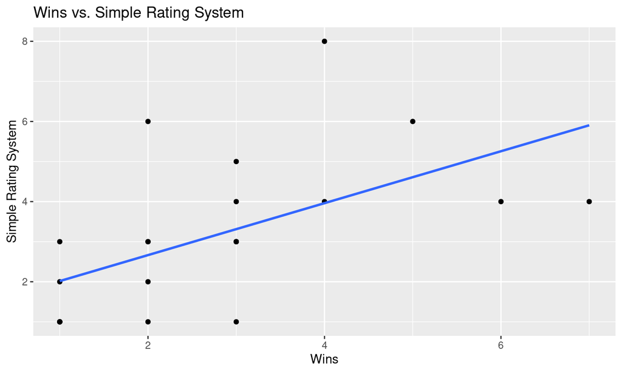

## Correlation Coefficient for W vs. SRS

```r
x = prev_year_data$W
y = prev_year_data$SRS
z <- cor(x, y)

print(z)
```

```
## [1] 0.565641
```

## This Seasons NBA Rankings

```
##                      Team Age  W PW MOV SOS SRS ORtg DRtg NRtg Pace
## 1          Boston Celtics  13  6  1   2  27   1    7    1    1   24
## 2            Phoenix Suns   8  1  1   1  30   2    4    3    1    8
## 3               Utah Jazz   2  9  3   3  29   3    1    9    3   22
## 4       Memphis Grizzlies  27  2  4   4  28   5    5    4    4    3
## 5   Golden State Warriors   7  3  4   5  17   4   17    1    4   13
## 6              Miami Heat   5  3  6   6  26   6   10    5    6   28
## 7        Dallas Mavericks  11  5  7   8  25   8   15    6    7   30
## 8         Milwaukee Bucks   4  6  8   7  23   7    3   14    8    7
## 9      Philadelphia 76ers  10  6  9  10  19   9   12   12    9   25
## 10 Minnesota Timberwolves  25 12  9   9  21  10    8   13   10    1
## 11         Denver Nuggets   6 10 11  11  24  12    6   15   11   19
## 12        Toronto Raptors  22 10 11  12  12  11   14    9   11   27
```

## Data Frame Findings (Donny)

```
##                      Team Age W MOV SRS ORtg DRtg NRtg Pace
## 1          Miami Heat 11'   5 4   4   4    8    4    4   15
## 2    Dallas Mavericks 10'   1 4   8   8    8    7    8   17
## 3  Los Angeles Lakers 09'   5 3   6   5   11    4    6   14
## 4  Los Angeles Lakers 08'   9 2   2   3    3    6    3    5
## 5      Boston Celtics 07'   8 1   1   1    9    1    1   19
## 6   San Antonio Spurs 06'   1 3   1   1    5    2    1   27
## 7          Miami Heat 05'   2 5   5   6    7    9    6   11
## 8   San Antonio Spurs 04'   3 2   1   1    8    1    1   23
## 9     Detroit Pistons 03'  12 6   2   4   18    2    2   24
## 10  San Antonio Spurs 02'   7 1   3   3    7    3    3   20
## 11 Los Angeles Lakers 01'  13 2   2   2    2    7    2    6
## 12 Los Angeles Lakers 00'   7 2   8   6    2   21    8   14
## 13                Average   6 3   3   3    6    6    3   14
```

## Comparison Table (Donny)

```
##                      Team row_mean
## 1               Utah Jazz    -1.17
## 2            Phoenix Suns    -0.83
## 3          Boston Celtics     0.17
## 4   Golden State Warriors     1.50
## 5         Milwaukee Bucks     2.75
## 6              Miami Heat     2.92
## 7        Dallas Mavericks     4.25
## 8          Denver Nuggets     4.83
## 9      Philadelphia 76ers     5.67
## 10      Memphis Grizzlies     5.75
## 11          Brooklyn Nets     8.17
## 12          Atlanta Hawks     8.33
## 13 Minnesota Timberwolves     9.08
## 14        Toronto Raptors    11.08
## 15          Chicago Bulls    11.75
## 16   New Orleans Pelicans    16.08
```

## Slide 2 (Emily Lantz)

```r
summary(prev_year_data_csv$Age)
```

```
##    Min. 1st Qu.  Median    Mean 3rd Qu.    Max.
##   1.000   3.250   5.000   5.818   7.000  16.000
```

## Slide 3 (Emily Lantz)

```r
summary(prev_year_data$W)
```

```
##    Min. 1st Qu.  Median    Mean 3rd Qu.    Max.
##   1.000   1.250   2.500   2.727   3.000   7.000
```

## Slide 4 (Emily Lantz)

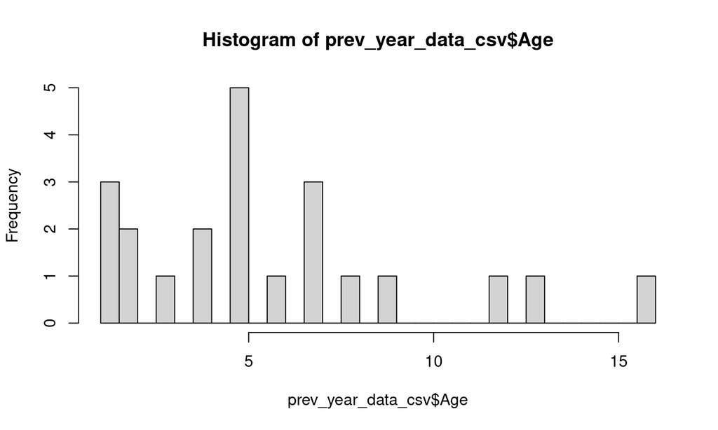

```r
hist(prev_year_data_csv$Age, breaks = 30)
```

## Slide 5 (Emily Lantz)

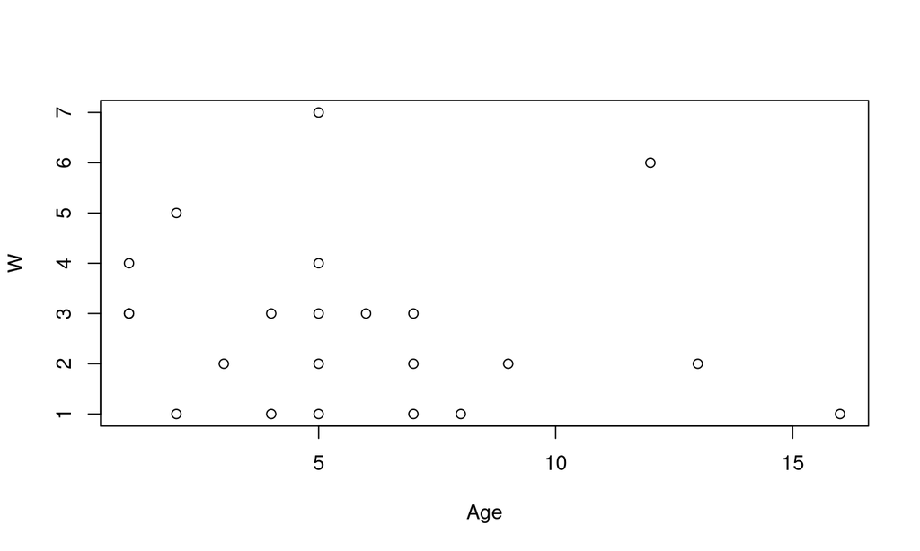

```r
plot(W ~ Age, data = prev_year_data_csv)
```

## Slide 6 (Emily Lantz)

```r
freq_Age_lm <- lm(W ~ Age, data=prev_year_data_csv)
```

## Slide 8 (Emily Lantz)

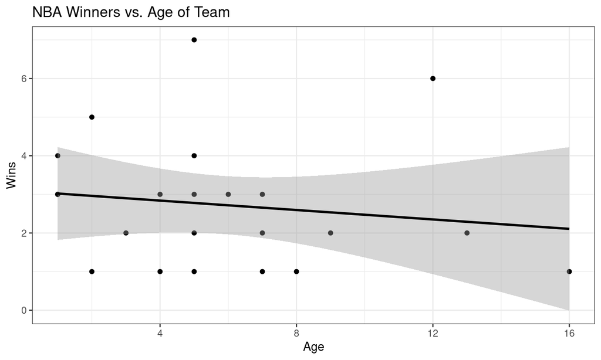

## Slide 9 (Emily Lantz)

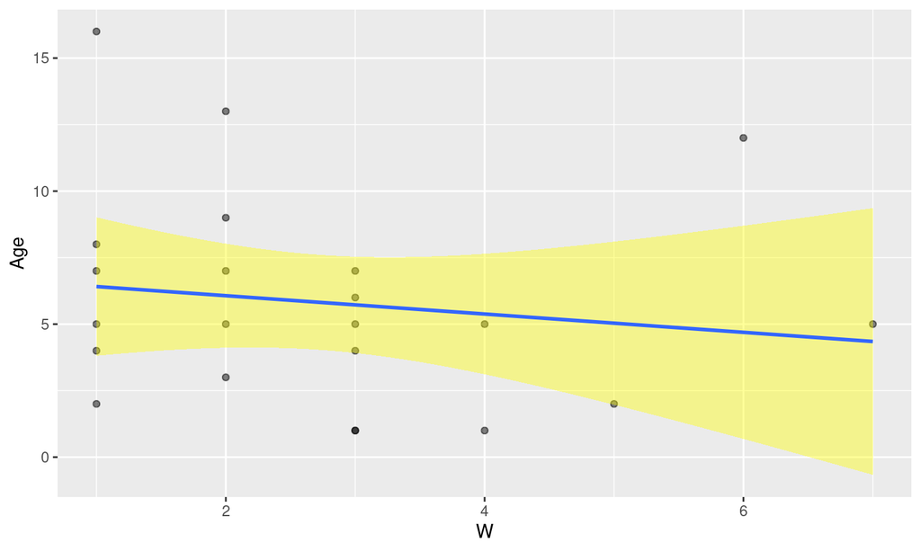

```r
ggplot(data=prev_year_data_csv, aes(x=W, y=Age))+ geom_point(alpha=0.5)+
  geom_smooth(method="lm", fill="yellow", se=TRUE)
```

## Slide 10 (Tate)

- *K-Nearest-Neighbors*
- Predicting Probability of winning a championship using 22 variables
- 10 seasons worth of data on every NBA team
- Classification based on probability

## Slide 11 (Tate)

- Prediction results on test data:

```
##
## knn_pred FALSE TRUE
##    FALSE    57    1
##    TRUE      1    1
```

- Test error rate

```
## [1] 0.03333333
```

## Slide 12 (Tate)

- Correctly predicted Cavaliers to win the 2015-2016 finals

```
## # A tibble: 4 × 5
##   Team                     Champ .pred_class .pred_FALSE .pred_TRUE
##   <chr>                    <fct> <fct>             <dbl>      <dbl>
## 1 Golden State Warriors*   FALSE FALSE             0.682      0.318
## 2 Oklahoma City Thunder*   FALSE FALSE             1          0
## 3 Cleveland Cavaliers 15'! TRUE  TRUE              0.318      0.682
## 4 Toronto Raptors*         FALSE FALSE             1          0
```

- Incorrectly predicted Raptors would win the 2019-2020 finals

```
## # A tibble: 1 × 5
##   Team             Champ .pred_class .pred_FALSE .pred_TRUE
##   <chr>            <fct> <fct>             <dbl>      <dbl>
## 1 Toronto Raptors* FALSE TRUE             0.0679      0.932
```